# grupo2-trabalho1

### Diagrama de Extremos e Quartis

```r
# Outliers
cat("\nOutliers\n")
```

```
##
## Outliers
```

```r
hour.cnt.outliers <- boxplot.stats(hour$cnt)$out
hour.cnt.outliers
```

[output not shown]

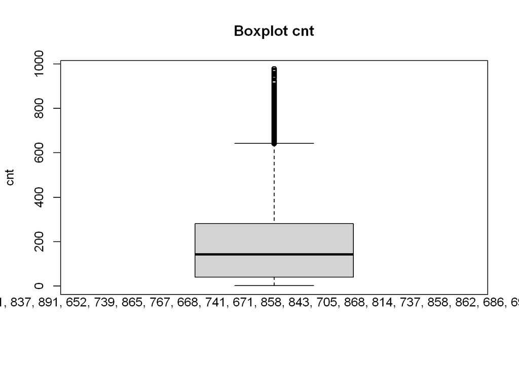

```r
# Diagrama
boxplot(hour$cnt, ylab="cnt", main="Boxplot cnt")

mtext(text = paste("outliers: ", paste(hour.cnt.outliers, collapse = ", ")), side = 1)
```

Verificou-se que existem bastantes outliers presentes no gráfico.

## **6.1. cnt**

### Classificação da variável

Variável qualitativa ordinal, e é tratada como quantitativa discreta normal, visto que, não tem grande variedade de variaveis distintas.

### Medidas de Tendência Central

#### Moda

```r
hour.day.cnt.moda <- moda(hour.day$cnt)
hour.day.cnt.moda
```

```
## [1] 224
```

#### Média

```r
hour.day.cnt.media <- mean(hour.day$cnt)
hour.day.cnt.media
```

```
## [1] 280.9225
```

#### Mediana

```r
hour.day.cnt.mediana <- median(hour.day$cnt)
hour.day.cnt.mediana
```

```
## [1] 237
```

#### Quartil

```r
hour.day.cnt.quantile <- quantile(hour.day$cnt)
hour.day.cnt.quantile
```

```
##   0%  25%  50%  75% 100%
##    1  142  237  382  977
```

### Medidas de Dispersão Central

#### Variância

```r
hour.day.cnt.variancia <- var(hour.day$cnt)
hour.day.cnt.variancia
```

```
## [1] 34893.5
```

#### Desvio Padrão

```r
hour.day.cnt.desvio_padrao <- sd(hour.day$cnt)
hour.day.cnt.desvio_padrao
```

```
## [1] 186.798
```

#### Coeficiente de Variação

```r
hour.day.cnt.coeficiente_variacao <- coeficiente_variacao(hour.day$cnt)
hour.day.cnt.coeficiente_variacao
```

```
## [1] 66.4945
```

### Valores Extremos

#### Máximo

```r
hour.day.cnt.maxima <- max(hour.day$cnt)
hour.day.cnt.maxima
```

```
## [1] 977
```

#### Mínimo

```r
hour.day.cnt.minima <- min(hour.day$cnt)
hour.day.cnt.minima
```

```
## [1] 1
```

### Medidas de Assimetria

```r
hour.day.cnt.assimetria <- assimetria(hour.day$cnt)
hour.day.cnt.assimetria
```

```
## [1] 0.9866874
```

De acordo com o resultado, é assimétrica positiva (ou enviesada para a direita).

### Medidas de Curtose ou Achatamento

```r
hour.day.cnt.achatamento <- achatamento(hour.day$cnt)
hour.day.cnt.achatamento
```

```
## [1] 0.6186668
```

Curva leptocúrtica, alongada, o que significa que os valores estão muito concentrados em torno da média e, consequentemente, existe uma variação é pouco elevada.

### Histograma

```r
# formula de sturges
cat("Número de classes\n")
```

```
## Número de classes
```

```r
hour.day.cnt.sturges.nclass <- sturges(hour.day$cnt)
hour.day.cnt.sturges.nclass
```

```
## [1] 14
```

```r
# amplitude da classe
cat("\nAmplitude da classe\n")
```

```
##
## Amplitude da classe
```

```r
hour.day.cnt.sturges.amplitude <- amplitude(hour.day$cnt)
hour.day.cnt.sturges.amplitude
```

```
## [1] 69.71429
```

```r
# tabela de frequencias
cat("\nClasses\n")
```

```
##
## Classes
```

```r
hour.day.cnt.sturges.breaks <- seq(hour.day.cnt.minima, hour.day.cnt.maxima, hour.day.cnt.sturges.amplitude)
hour.day.cnt.sturges.breaks
```

```
##  [1]   1.00000  70.71429 140.42857 210.14286 279.85714 349.57143 419.28571
##  [8] 489.00000 558.71429 628.42857 698.14286 767.85714 837.57143 907.28571
## [15] 977.00000
```

```r
cat("\nTabela de frequências\n")
```

```
##
## Tabela de frequências
```

```r
table(cut(hour.day$cnt, breaks=hour.day.cnt.sturges.breaks))
```

```
##
##   (1,70.7] (70.7,140]  (140,210]  (210,280]  (280,350]  (350,419]  (419,489]
##        812       1329       1616       1370       1035        760        541
##  (489,559]  (559,628]  (628,698]  (698,768]  (768,838]  (838,907]  (907,977]
##        434        312        204        130        108         69         15
```

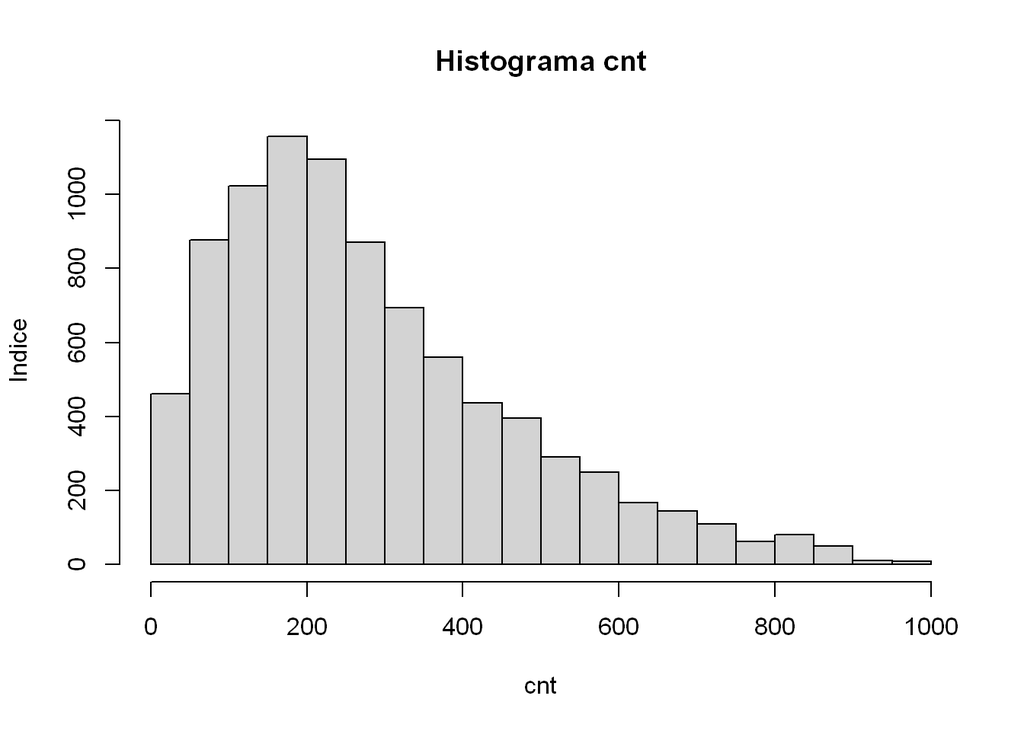

```r
# histograma
hist(hour.day$cnt, main="Histograma cnt", xlab="cnt",  ylab="Indice", nclass=hour.day.cnt.sturges.nclass)
```

### Diagrama de Extremos e Quartis

```r
# Outliers
cat("\nOutliers\n")
```

```
##
## Outliers
```

```r
hour.day.cnt.outliers <- boxplot.stats(hour.day$cnt)$out
hour.day.cnt.outliers
```

[output not shown]

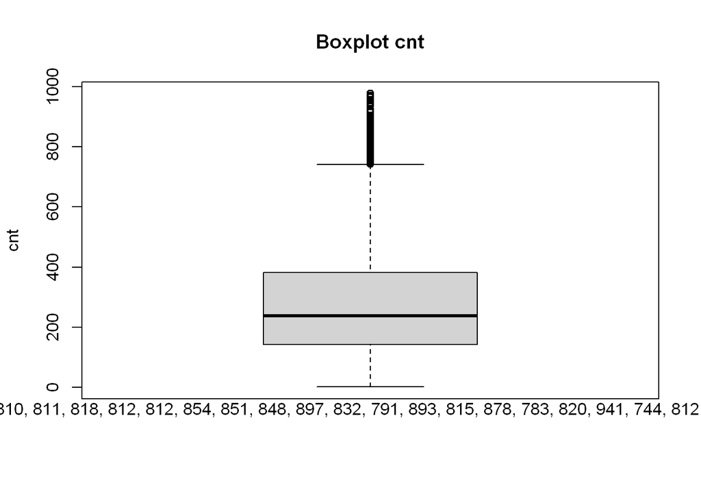

```r
# Diagrama
boxplot(hour.day$cnt, ylab="cnt", main="Boxplot cnt")
mtext(text = paste("outliers: ", paste(hour.day.cnt.outliers, collapse = ", ")), side = 1)
```

Verificou-se que existem bastantes outliers presentes no gráfico.

## **6.2. cnt**

### Classificação da Variável

Variável qualitativa ordinal, e é tratada como quantitativa discreta normal, visto que, não tem grande variedade de variaveis distintas.

### Medidas de Tendência Central

#### Moda

```r
hour.night.cnt.moda <- moda(hour.night$cnt)
hour.night.cnt.moda
```

```
## [1] 5
```

#### média

```r
hour.night.cnt.media <- mean(hour.night$cnt)
hour.night.cnt.media
```

```
## [1] 96.97697
```

#### Mediana

```r
hour.night.cnt.mediana <- median(hour.night$cnt)
hour.night.cnt.mediana
```

```
## [1] 48
```

#### Quartil

```r
hour.night.cnt.quantile <- quantile(hour.night$cnt)
hour.night.cnt.quantile
```

```
##   0%  25%  50%  75% 100%
##    1   12   48  140  743
```

### Medidas de Dispersão Central

#### Variância

```r
hour.night.cnt.variancia <- var(hour.night$cnt)
hour.night.cnt.variancia
```

```
## [1] 13876.49
```

#### Desvio Padrão

```r
hour.night.cnt.desvio_padrao <- sd(hour.night$cnt)
hour.night.cnt.desvio_padrao
```

```
## [1] 117.7985
```

#### Coeficiente de variação

```r
hour.night.cnt.coeficiente_variacao <- coeficiente_variacao(hour.night$cnt)
hour.night.cnt.coeficiente_variacao
```

```
## [1] 121.4706
```